# Symmetrical Selection

Heath Blackmon

10/26/2017

## 1+s or 1-s or 1/1+s or 1/1-s

First lets look at a system where we have genotypes that have fitness defined as $1+s$. However, we might want $s$ to have both positive and negative values so that we can have beneficial and deleterious mutations. Will the same absolute value of $s$ have a proportionally strong impact whether it is positive or negative? Below we see what happens:

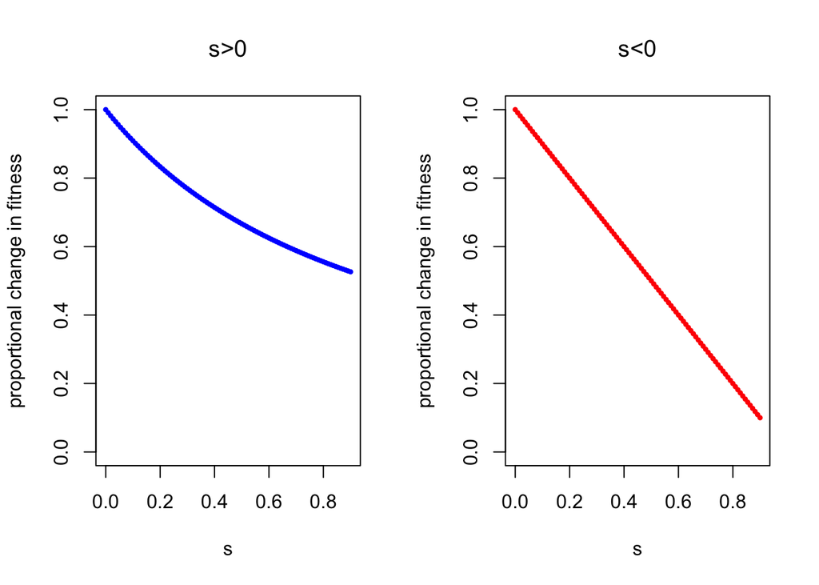

```r
f <- function(s) 1+s
s <- seq(from = 0, to = 0.9, length.out = 100)
par(mfcol=c(1,2))
plot(x = s, y = 1/f(s),
     col ="blue",
     ylim = c(0, 1),
     ylab = "proportional change in fitness",
     pch = 16, cex = .6,
     main="s>0")
plot(x = s, y = f(-s)/1,
     col ="red",
     ylim = c(0, 1),
     ylab = "proportional change in fitness",
     pch = 16, cex = .6,
     main="s<0")
```

Because fitness is always normalized the same absolute values of $s$ cause differences in the relative deviation from a fitness of 1. In this case deleterious mutations have a larger effect than beneficial mutations particularly as $s$ becomes large.

There is pretty straight forward fix for this problem. Instead of having $1+s$ and varying $s$ to include both positive and negative we instead us $1+s$ for beneficial mutations and $\frac{1}{1+s}$ for deleterious mutations

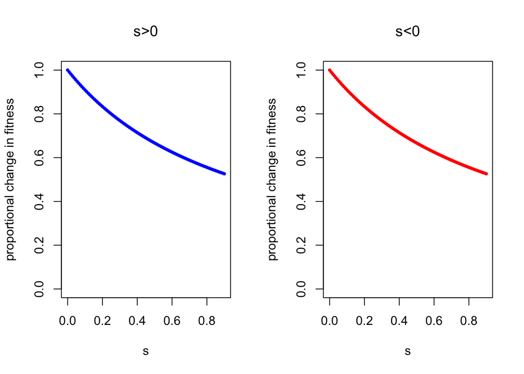

```r
f1 <- function(s) 1+s
f2 <- function(s) 1/(1+s)
s <- seq(from = 0, to = 0.9, length.out = 100)
par(mfcol=c(1,2))
plot(x = s, y = 1/f1(s),
     col ="blue",
     ylim = c(0, 1),
     ylab = "proportional change in fitness",
     pch = 16, cex = .6,
     main="s>0")
plot(x = s, y = f2(s)/1,
     col ="red",
     ylim = c(0, 1),
     ylab = "proportional change in fitness",
     pch = 16, cex = .6,
     main="s<0")
```

What if the original formulation was in 1-s? The same problem would exist

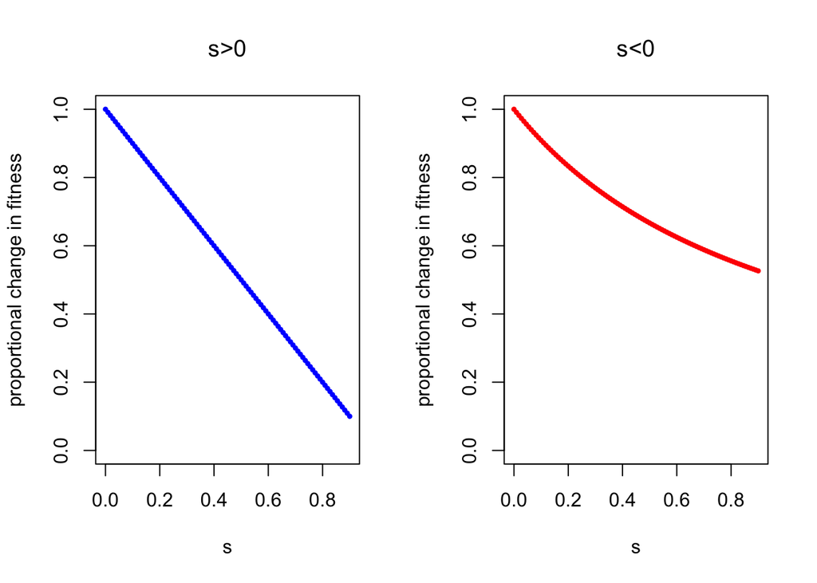

```r
f <- function(s) 1-s
s <- seq(from = 0, to = 0.9, length.out = 100)
par(mfcol=c(1,2))
plot(x = s, y = f(s)/1,
     col ="blue",
     ylim = c(0, 1),
     ylab = "proportional change in fitness",
     pch = 16, cex = .6,
     main="s>0")
plot(x = s, y = 1/f(-s),
     col ="red",
     ylim = c(0, 1),
     ylab = "proportional change in fitness",
     pch = 16, cex = .6,
     main="s<0")
```

However we can fix it in exactly the same way: we will now use $1-s$ for deleterious and $\frac{1}{1-s}$ for beneficial.

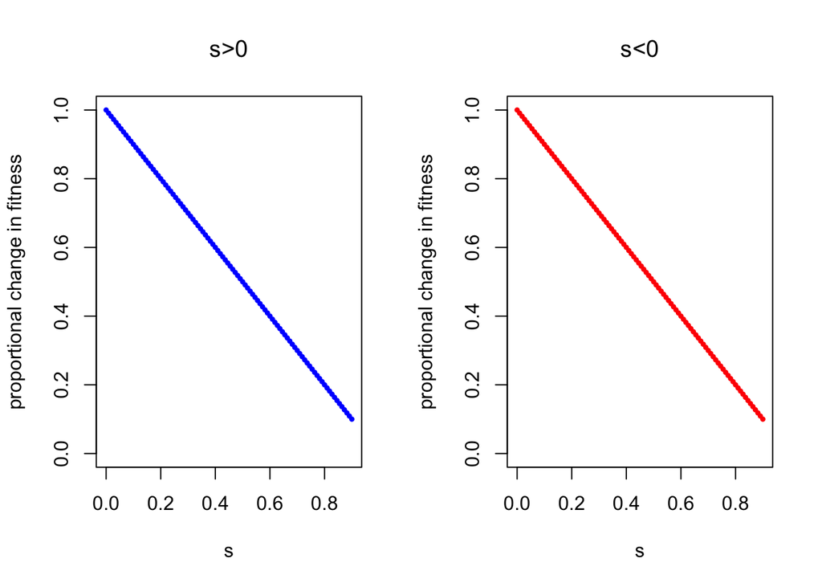

```r
f1 <- function(s) 1-s
f2 <- function(s) 1/(1-s)
s <- seq(from = 0, to = 0.9, length.out = 100)
par(mfcol=c(1,2))
plot(x = s, y = f1(s)/1,
     col ="blue",
     ylim = c(0, 1),
     ylab = "proportional change in fitness",
     pch = 16, cex = .6,
     main="s>0")
plot(x = s, y = 1/f2(s),
     col ="red",
     ylim = c(0, 1),
     ylab = "proportional change in fitness",
     pch = 16, cex = .6,
     main="s<0")
```

We now have a way to give beneficial and deleterious mutations symmetrical strength using either the $1-s$ or $1+s$ starting point. It should be noted though that in the case of the $1+s$ approach as $s$ becomes large its impact on fitness plateaus. in contrast the $1-s$ the effect is linear across values of $s$.